# Estudios de Informática, Multimedia y Telecomunicaciones

# Minería de datos: PEC2 - Métodos no supervisados

Autor: Vinicio Naranjo Mosquera

Marzo 2024

# 1 Ejercicios

Los ejercicios se realizarán en base al juego de datos *Hawks* presente en el paquete R *Stat2Data*.

Los estudiantes y el profesorado del Cornell College en Mount Vernon, Iowa, recogieron datos durante muchos años en el mirador de halcones del lago MacBride, cerca de Iowa City, en el estado de Iowa. El conjunto de datos que analizamos aquí es un subconjunto del conjunto de datos original, utilizando sólo aquellas especies para las que había más de 10 observaciones. Los datos se recogieron en muestras aleatorias de tres especies diferentes de halcones: Colirrojo, Gavilán y Halcón de Cooper.

Hemos seleccionado este juego de datos por su parecido con el juego de datos *penguins* y por su potencial a la hora de aplicarle algoritmos de minería de datos no supervisados. Las variables numéricas en las que os basaréis son: *Wing*, *Weight*, *Culmen*, *Hallux*

```r
if (!require('Stat2Data')) install.packages('Stat2Data')
library(Stat2Data)
data("Hawks")
summary(Hawks)
```

```
##      Month             Day             Year       CaptureTime   ReleaseTime
##  Min.   : 8.000   Min.   : 1.00   Min.   :1992   11:35  : 14          :842
##  1st Qu.: 9.000   1st Qu.: 9.00   1st Qu.:1995   13:30  : 14   11:00  :  2
##  Median :10.000   Median :16.00   Median :1999   11:45  : 13   11:35  :  2
##  Mean   : 9.843   Mean   :15.74   Mean   :1998   12:10  : 13   12:05  :  2
##  3rd Qu.:10.000   3rd Qu.:23.00   3rd Qu.:2001   14:00  : 13   12:50  :  2
##  Max.   :11.000   Max.   :31.00   Max.   :2003   13:05  : 12   13:32  :  2
##                                                  (Other):829   (Other): 56
##       BandNumber  Species  Age     Sex          Wing           Weight
##            :  2   CH: 70   A:224    :576   Min.   : 37.2   Min.   :  56.0
##  1142-09240:  1   RT:577   I:684   F:174   1st Qu.:202.0   1st Qu.: 185.0
##  1142-09241:  1   SS:261           M:158   Median :370.0   Median : 970.0
##  1142-09242:  1                            Mean   :315.6   Mean   : 772.1
##  1142-18229:  1                            3rd Qu.:390.0   3rd Qu.:1120.0
##  1142-19209:  1                            Max.   :480.0   Max.   :2030.0
##  (Other)   :901                            NA's   :1       NA's   :10
##      Culmen         Hallux            Tail        StandardTail
##  Min.   : 8.6   Min.   :  9.50   Min.   :119.0   Min.   :115.0
##  1st Qu.:12.8   1st Qu.: 15.10   1st Qu.:160.0   1st Qu.:162.0
##  Median :25.5   Median : 29.40   Median :214.0   Median :215.0
##  Mean   :21.8   Mean   : 26.41   Mean   :198.8   Mean   :199.2
##  3rd Qu.:27.3   3rd Qu.: 31.40   3rd Qu.:225.0   3rd Qu.:226.0
##  Max.   :39.2   Max.   :341.40   Max.   :288.0   Max.   :335.0
##  NA's   :7      NA's   :6                        NA's   :337
##      Tarsus        WingPitFat        KeelFat           Crop
##  Min.   :24.70   Min.   :0.0000   Min.   :0.000   Min.   :0.0000
##  1st Qu.:55.60   1st Qu.:0.0000   1st Qu.:2.000   1st Qu.:0.0000
##  Median :79.30   Median :1.0000   Median :2.000   Median :0.0000
##  Mean   :71.95   Mean   :0.7922   Mean   :2.184   Mean   :0.2345
##  3rd Qu.:87.00   3rd Qu.:1.0000   3rd Qu.:3.000   3rd Qu.:0.2500
##  Max.   :94.00   Max.   :3.0000   Max.   :4.000   Max.   :5.0000
##  NA's   :833     NA's   :831      NA's   :341     NA's   :343
```

## 1.1 Ejercicio 1

Presenta el juego de datos, nombre y significado de cada columna, así como las distribuciones de sus valores.

Realiza un estudio aplicando el método K-means, similar al de los ejemplos 1.1 y 1.2

### 1.1.1 Respuesta 1

```r
contador <- nrow(Hawks)
print(contador)
```

```
## [1] 908
```

```r
# Primero, revisamos la cantidad de valores NA en cada una de las columnas de interés

# Para la columna Wing
cat("Valores NA en Wing:", sum(is.na(Hawks$Wing)), "\n")
```

```
## Valores NA en Wing: 1
```

```r
# Para la columna Weight
cat("Valores NA en Weight:", sum(is.na(Hawks$Weight)), "\n")
```

```
## Valores NA en Weight: 10
```

```r
# Para la columna Culmen
cat("Valores NA en Culmen:", sum(is.na(Hawks$Culmen)), "\n")
```

```
## Valores NA en Culmen: 7
```

```r
# Para la columna Hallux
cat("Valores NA en Hallux:", sum(is.na(Hawks$Hallux)), "\n")
```

```
## Valores NA en Hallux: 6
```

En el total de 908 registros hay valores NA en las cuatro columnas de interés: 1 en Wing, 10 en Weight, 7 en Culmen y 6 en Hallux.

Descripción de las variables:

- Wing: Longitud del ala del halcón en milímetros. Esta medida puede ser indicativa del tamaño general y la capacidad de vuelo del ave.
- Weight: Peso del halcón en gramos. Es un indicador clave de la salud y el bienestar del ave, así como de su capacidad para cazar y sobrevivir.
- Culmen: Longitud del culmen (parte superior del pico) en milímetros. Puede indicar adaptaciones específicas para diferentes tipos de dieta.
- Hallux: Longitud del hallux (dedo trasero) en milímetros. Es importante para agarrar y sujetar presas.

Las demás columnas proporcionan información adicional sobre cada observación, como:

- rownames: Un identificador único para cada observación.
- Month, Day, Year: Fecha de la observación.
- CaptureTime, ReleaseTime: Hora de captura y liberación del halcón.
- BandNumber: Número de banda o anillo identificativo puesto al halcón.
- Species: Especie del halcón observado. Las abreviaturas representan diferentes especies.
- Age: Edad del halcón, indicada como inmaduro (I) o adulto (A).
- Sex: Sexo del halcón, si es conocido.
- Tail: Longitud de la cola en milímetros.
- StandardTail, Tarsus, WingPitFat, KeelFat, Crop: Otras mediciones y observaciones realizadas que podrían no estar completas para todos los registros.

#### 1.1.1.1 Eliminación de filas con valores NA

```r
# Selecciono las columnas de interés que no tienen NA
hawks_clean <- Hawks[complete.cases(Hawks[, c("Wing", "Weight", "Culmen", "Hallux")]), ]

contador <- nrow(hawks_clean)
print(contador)
```

```
## [1] 891
```

```r
# Para la columna Wing
cat("Valores NA en Wing:", sum(is.na(hawks_clean$Wing)), "\n")
```

```
## Valores NA en Wing: 0
```

```r
# Para la columna Weight
cat("Valores NA en Weight:", sum(is.na(hawks_clean$Weight)), "\n")
```

```
## Valores NA en Weight: 0
```

```r
# Para la columna Culmen
cat("Valores NA en Culmen:", sum(is.na(hawks_clean$Culmen)), "\n")
```

```
## Valores NA en Culmen: 0
```

```r
# Para la columna Hallux
cat("Valores NA en Hallux:", sum(is.na(hawks_clean$Hallux)), "\n")
```

```
## Valores NA en Hallux: 0
```

Ahora, examinemos las distribuciones de los valores de las variables numéricas de interés (Wing, Weight, Culmen, y Hallux)

```r
# Cargando las librerías necesarias
library(ggplot2)

# Calculando estadísticas descriptivas para las columnas de interés
estadisticas_descriptivas <- summary(hawks_clean[,c("Wing", "Weight", "Culmen", "Hallux")])
print(estadisticas_descriptivas)
```

```
##       Wing           Weight           Culmen          Hallux
##  Min.   : 37.2   Min.   :  56.0   Min.   : 8.60   Min.   :  9.50
##  1st Qu.:202.0   1st Qu.: 185.0   1st Qu.:12.80   1st Qu.: 15.10
##  Median :370.0   Median : 970.0   Median :25.50   Median : 29.40
##  Mean   :315.9   Mean   : 771.6   Mean   :21.81   Mean   : 26.41
##  3rd Qu.:390.0   3rd Qu.:1120.0   3rd Qu.:27.35   3rd Qu.: 31.40
##  Max.   :480.0   Max.   :2030.0   Max.   :39.20   Max.   :341.40
```

```r
# Calculo de la desviacion estandar.
sd(hawks_clean$Wing)
```

```
## [1] 95.3167
```

```r
sd(hawks_clean$Weight)
```

```
## [1] 462.9369
```

```r
sd(hawks_clean$Culmen)
```

```
## [1] 7.29319
```

```r
sd(hawks_clean$Hallux)
```

```
## [1] 17.82554
```

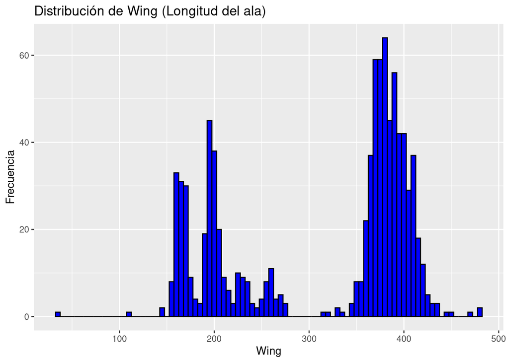

```r
# Creando histogramas para cada una de las variables numéricas de interés
p1 <- ggplot(hawks_clean, aes(x=Wing)) + geom_histogram(binwidth=5, fill="blue", color="black") +
  ggtitle("Distribución de Wing (Longitud del ala)") + xlab("Wing") + ylab("Frecuencia")

p2 <- ggplot(hawks_clean, aes(x=Weight)) + geom_histogram(binwidth=10, fill="red", color="black") +
  ggtitle("Distribución de Weight (Peso)") + xlab("Weight") + ylab("Frecuencia")

p3 <- ggplot(hawks_clean, aes(x=Culmen)) + geom_histogram(binwidth=1, fill="green", color="black") +
  ggtitle("Distribución de Culmen (Longitud del culmen)") + xlab("Culmen") + ylab("Frecuencia")

p4 <- ggplot(hawks_clean, aes(x=Hallux)) + geom_histogram(binwidth=1, fill="orange", color="black") +
  ggtitle("Distribución de Hallux (Longitud del hallux)") + xlab("Hallux") + ylab("Frecuencia")

# Imprimiendo uno por uno
print(p1)
```

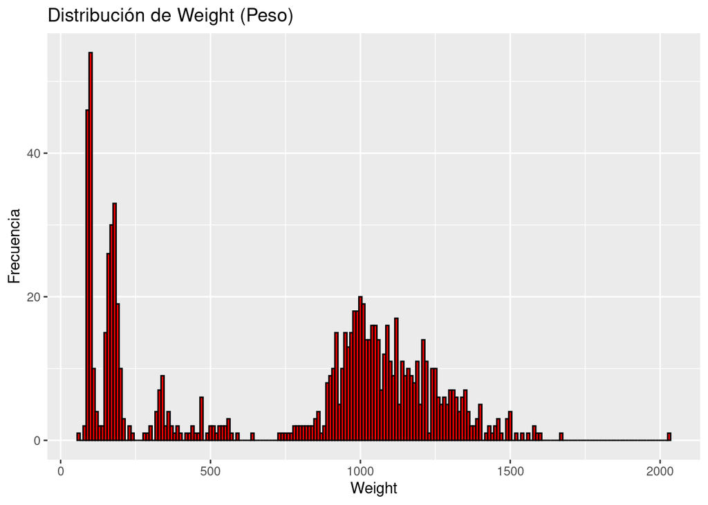

```r
print(p2)
```

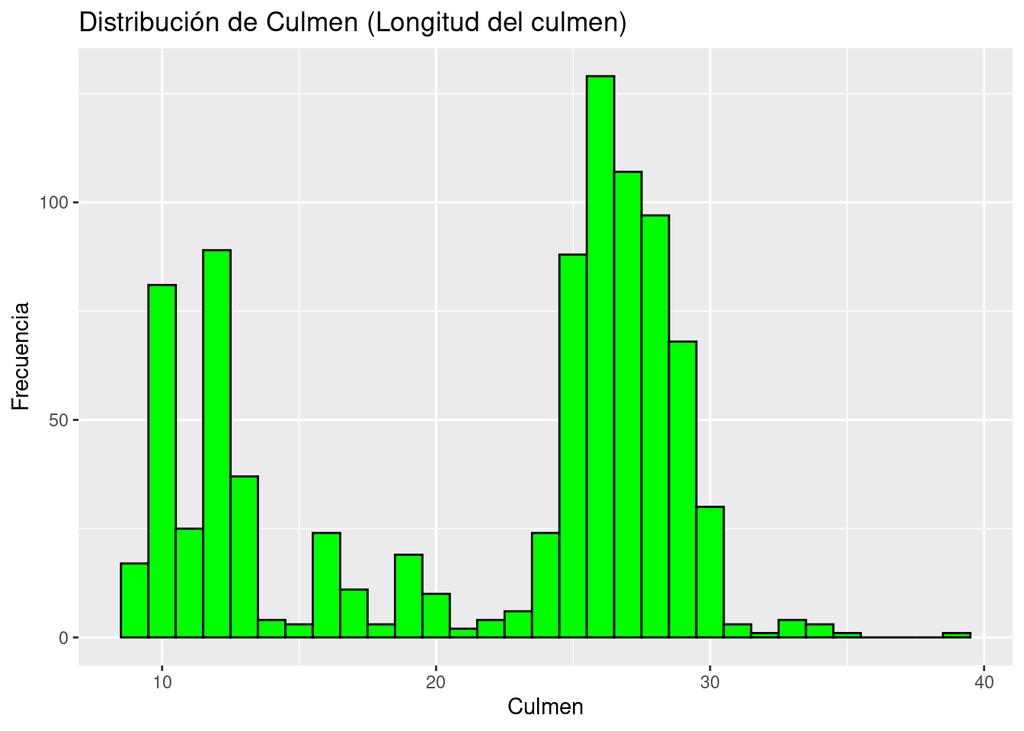

```r
print(p3)
```

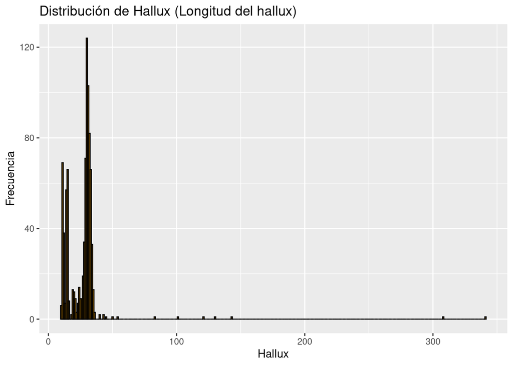

```r
print(p4)
```

Las estadísticas descriptivas y las distribuciones de las variables numéricas “Wing”, “Weight”, “Culmen”, y “Hallux” muestran una interesante variedad en sus valores:

- Wing: La longitud de las alas tiene un promedio de 315.9 mm, con una desviación estándar de 95.32 mm. La distribución es bastante amplia, indicando una variabilidad significativa en el tamaño de las alas entre los halcones.
- Weight: El peso promedio es de 771.6 g, pero la desviación estándar es alta (462.94 g), lo que sugiere una gran diversidad en el peso de estas aves. Los valores oscilan entre 56 g y 2030 g.
- Culmen: Para el culmen, la longitud promedio es de 21.81 mm, con una desviación estándar de 7.29 mm. Esto indica menos variabilidad que en las otras medidas, pero aún así hay una gama significativa.
- Hallux: La longitud del hallux tiene un promedio de 26.41 mm. Sin embargo, la desviación estándar es de 17.83 mm, algo inflada por un valor máximo muy alejado de la media (341.4 mm), lo que podría indicar la presencia de valores atípicos extremos o errores de medición.

El hecho de que la desviación estándar sea tan alta y que el valor máximo esté tan alejado de la media (341.4 mm comparado con una media de 26.41 mm) es un fuerte indicativo de un valor atípico extremo. Este tipo de valores pueden distorsionar el análisis y afectar significativamente los resultados de algoritmos como k-means, que son sensibles a outliers porque se basan en calcular distancias para asignar puntos a clústeres.

Aplicare una estandarización de los datos para ayudar a minimizar el efecto de cualquier valor atípico restante.

Las distribuciones de estas variables se visualizan en los histogramas. La presencia de una distribución bimodal en algunas variables sugiere que podría haber subpoblaciones dentro de los datos, posiblemente relacionadas con diferencias entre especies, edades o sexos de los halcones.

#### 1.1.1.2 Distrubuciónes de los valores de las variables numéricas de interés sin limpiar (Wing, Weight, Culmen, y Hallux):

```r
contador <- nrow(Hawks)
print(contador)
```

```
## [1] 908
```

```r
# Calculando estadísticas descriptivas para las columnas de interés
estadisticas_descriptivas <- summary(Hawks[,c("Wing", "Weight", "Culmen", "Hallux")])
print(estadisticas_descriptivas)
```

```
##       Wing           Weight           Culmen         Hallux
##  Min.   : 37.2   Min.   :  56.0   Min.   : 8.6   Min.   :  9.50
##  1st Qu.:202.0   1st Qu.: 185.0   1st Qu.:12.8   1st Qu.: 15.10
##  Median :370.0   Median : 970.0   Median :25.5   Median : 29.40
##  Mean   :315.6   Mean   : 772.1   Mean   :21.8   Mean   : 26.41
##  3rd Qu.:390.0   3rd Qu.:1120.0   3rd Qu.:27.3   3rd Qu.: 31.40
##  Max.   :480.0   Max.   :2030.0   Max.   :39.2   Max.   :341.40
##  NA's   :1       NA's   :10       NA's   :7      NA's   :6
```

```r
# Calculo de la desviacion estandar: El argumento na.rm = TRUE indica a R que ignore los valores NA al calcular la desviación estándar.
sd(Hawks$Wing, na.rm = TRUE)
```

```
## [1] 95.27759
```

```r
sd(Hawks$Weight, na.rm = TRUE)
```

```
## [1] 462.3118
```

```r
sd(Hawks$Culmen, na.rm = TRUE)
```

```
## [1] 7.284175
```

```r
sd(Hawks$Hallux, na.rm = TRUE)
```

```
## [1] 17.7347
```

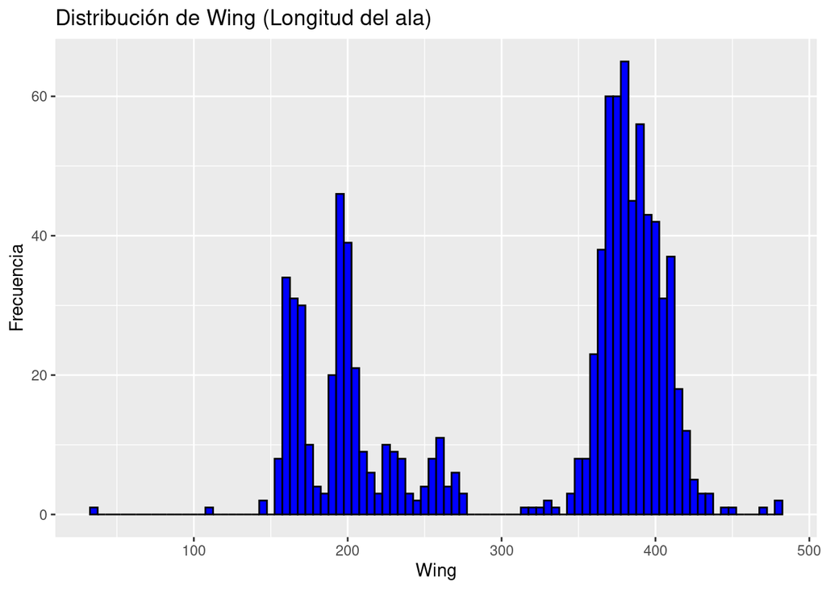

```r
# Creando histogramas para cada una de las variables numéricas de interés
p1 <- ggplot(Hawks, aes(x=Wing)) + geom_histogram(binwidth=5, fill="blue", color="black") +
  ggtitle("Distribución de Wing (Longitud del ala)") + xlab("Wing") + ylab("Frecuencia")

p2 <- ggplot(Hawks, aes(x=Weight)) + geom_histogram(binwidth=10, fill="red", color="black") +
  ggtitle("Distribución de Weight (Peso)") + xlab("Weight") + ylab("Frecuencia")

p3 <- ggplot(Hawks, aes(x=Culmen)) + geom_histogram(binwidth=1, fill="green", color="black") +
  ggtitle("Distribución de Culmen (Longitud del culmen)") + xlab("Culmen") + ylab("Frecuencia")

p4 <- ggplot(Hawks, aes(x=Hallux)) + geom_histogram(binwidth=1, fill="orange", color="black") +
  ggtitle("Distribución de Hallux (Longitud del hallux)") + xlab("Hallux") + ylab("Frecuencia")

# Visualizar los gráficos, imprimiendo uno por uno
print(p1)
```

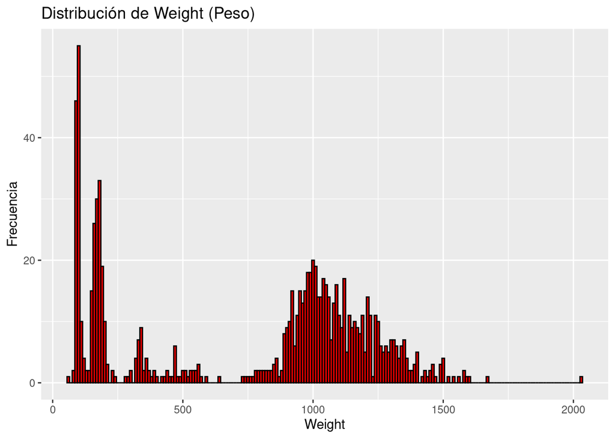

```r
print(p2)
```

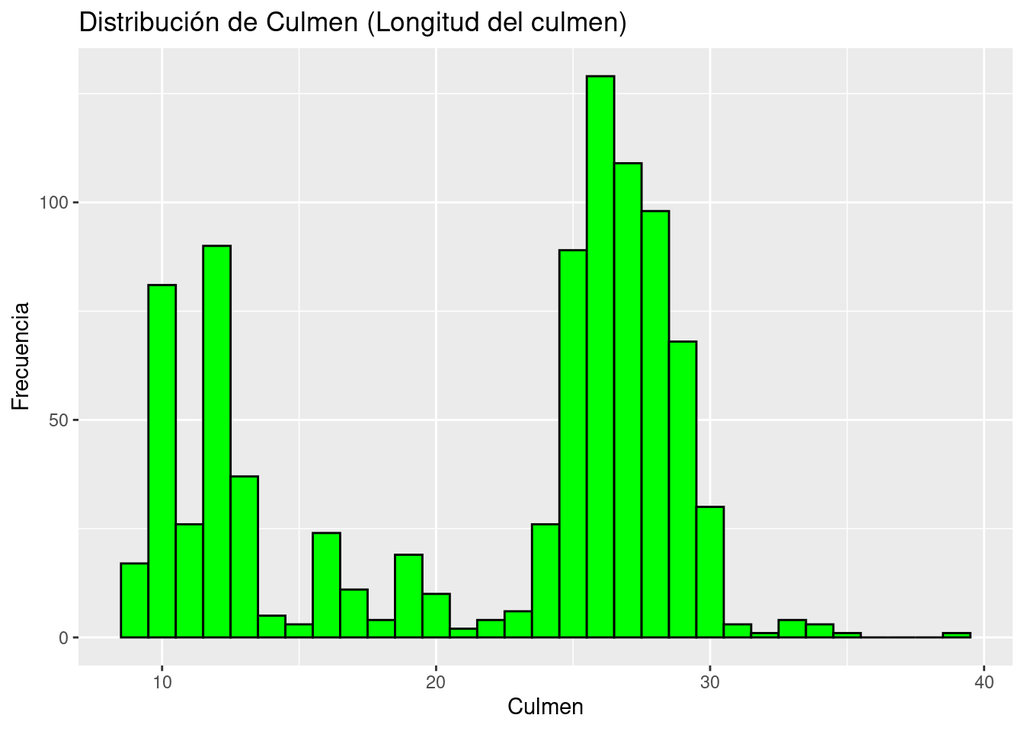

```r
print(p3)
```

```r
print(p4)
```

```
## Warning: Removed 6 rows containing non-finite values (`stat_bin()`).
```

[figure not shown]

La advertencia Removed 6 rows containing non-finite values (stat_bin()) indica que ggplot2 ha eliminado 6 filas que contienen valores no finitos para poder crear el gráfico.

Añado esto para recalcar la importancia de eliminar los valores NA o vacios.

#### 1.1.1.3 Analisis de cluster con los datos limpios:

##### 1.1.1.3.1 Metodo del codo:

```r
library(cluster) # para la función silhouette
library(factoextra) # para fviz_nbclust (visualización)
# Asegurándonos de limpiar los datos correctamente y escalarlos
hawks_clean <- na.omit(Hawks[,c("Wing", "Weight", "Culmen", "Hallux")])

# Estandarización de los datos
hawks_clean_scaled <- scale(hawks_clean)

# Comprobamos que hawks_clean_scaled es una matriz numérica
if(is.matrix(hawks_clean_scaled)) {
  print("hawks_clean_scaled es una matriz")
} else {
  print("hawks_clean_scaled no es una matriz")
}
```

```
## [1] "hawks_clean_scaled es una matriz"
```

```r
contador <- nrow(hawks_clean_scaled)
print(contador)
```

```
## [1] 891
```

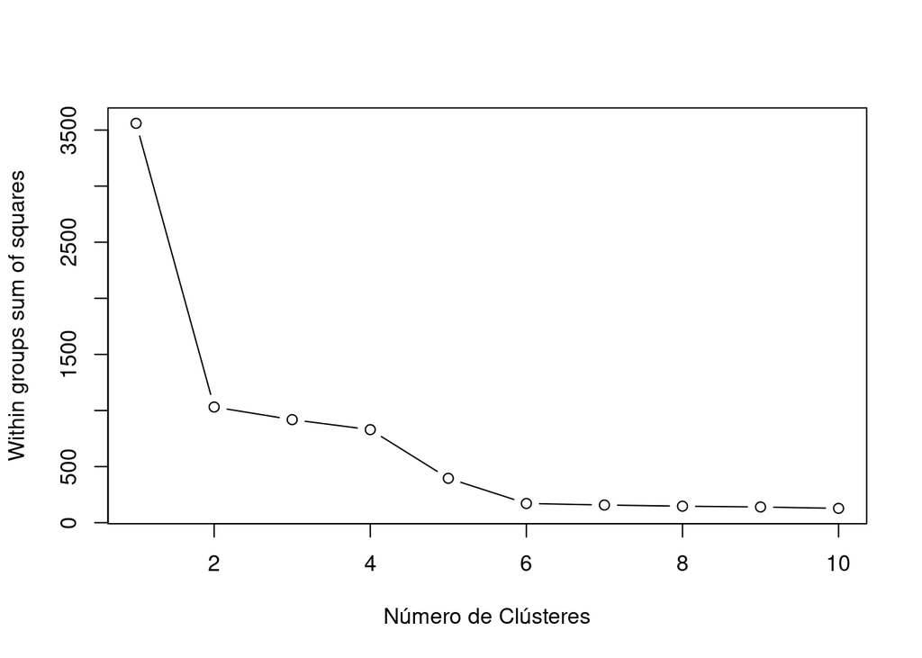

```r
# Analizando el número óptimo de clústeres
set.seed(123) # Para reproducibilidad

# Método del codo
wss <- (nrow(hawks_clean_scaled)-1)*sum(apply(hawks_clean_scaled,2,var))
for (i in 2:10) wss[i] <- sum(kmeans(hawks_clean_scaled, centers=i)$withinss)
plot(1:10, wss, type="b", xlab="Número de Clústeres", ylab="Within groups sum of squares")
```

##### 1.1.1.3.2 Metodo de la silueta:

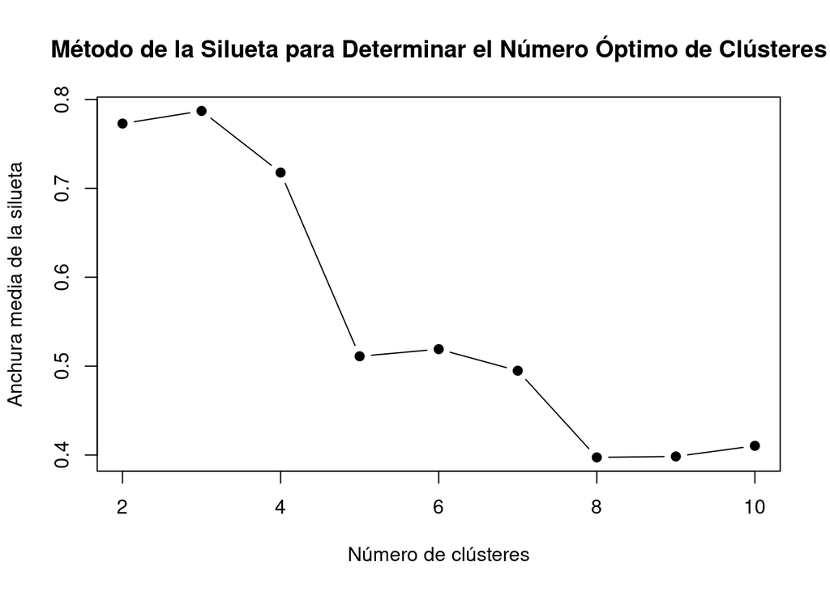

```r
# Calculamos los valores de silueta para diferentes números de clústeres
sil_widths <- numeric(9)  # Para almacenar los promedios de las anchuras de silueta

for(k in 2:10) {
  km_res <- kmeans(hawks_clean_scaled, centers = k, nstart = 25)
  silhouette_res <- silhouette(km_res$cluster, dist(hawks_clean_scaled))
  sil_widths[k-1] <- mean(silhouette_res[, 3])  # Almacenamos la anchura media de la silueta
}

# Visualizamos los resultados
plot(2:10, sil_widths, type = "b", pch = 19, xlab = "Número de clústeres", ylab = "Anchura media de la silueta",
     main = "Método de la Silueta para Determinar el Número Óptimo de Clústeres")
```

```r
# Identificamos el número de clústeres con la mayor anchura media de la silueta
optimal_clusters <- which.max(sil_widths) + 1  # Sumamos 1 porque nuestro ciclo inicia en 2
cat("El número óptimo de clústeres sugerido por la silueta es:", optimal_clusters, "\n")
```

```
## El número óptimo de clústeres sugerido por la silueta es: 3
```

```r
# Comprobamos que hawks_clean_scaled es una matriz numérica
if(is.matrix(hawks_clean_scaled)) {
  print("hawks_clean_scaled es una matriz")
} else {
  print("hawks_clean_scaled no es una matriz")
}
```

```
## [1] "hawks_clean_scaled es una matriz"
```

La función scale() en R, centra y escala las variables. Esto significa que a cada valor de las variables se le restará la media de la variable y luego se dividirá por la desviación estándar de la misma. El resultado es que cada variable tendrá una media de cero y una desviación estándar de uno.

Esto es precisamente lo que se busca con la estandarización (también conocida como Z-score normalization):

Centrar la media: La media de cada variable se ajusta a 0, lo que ayuda en técnicas como k-means a no ser sesgado por ubicaciones diferentes de los centroides iniciales.

Escalar por la desviación estándar: Esto asegura que todas las variables contribuyan equitativamente al análisis, ya que todas tienen la misma escala de varianza (1).

```r
set.seed(123) # Para reproducibilidad

# Comprobamos que hawks_clean_scaled es una matriz numérica
if(is.matrix(hawks_clean_scaled)) {
  print("hawks_clean_scaled es una matriz")
} else {
  print("hawks_clean_scaled no es una matriz")
}
```

```
## [1] "hawks_clean_scaled es una matriz"
```

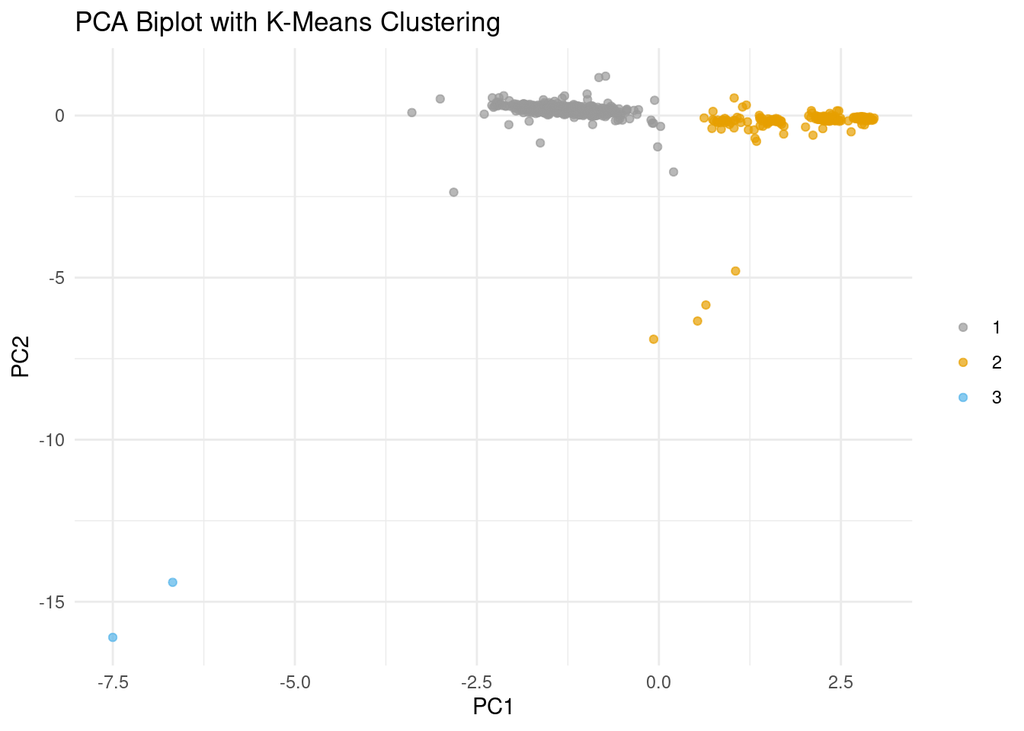

```r
# Aplicar K-Means con 3 clústeres
kmeans_result <- kmeans(hawks_clean_scaled, centers=3, nstart=25)

# Guardo la asignación de clústeres en un objeto separado, no en la matriz escalada
cluster_assignments <- as.factor(kmeans_result$cluster)

# Aplicar PCA sin incluir la última columna, que ya no existe como tal
# Aseguramos que hawks_clean_scaled no ha sido modificado desde su escalado
pca_result <- prcomp(hawks_clean_scaled, center = TRUE, scale. = TRUE)

# Crear un data frame con los resultados de PCA para ggplot
pca_data <- data.frame(pca_result$x)
# Añadimos la asignación de clústeres desde el objeto separado
pca_data$cluster <- cluster_assignments

# Gráfico de PCA con ggplot2
ggplot(pca_data, aes(x = PC1, y = PC2, color = cluster)) +
  geom_point(alpha = 0.7) +
  scale_color_manual(values = c("#999999", "#E69F00", "#56B4E9")) + # Colores manuales para clusters
  theme_minimal() +
  ggtitle("PCA Biplot with K-Means Clustering") +
  xlab("PC1") +
  ylab("PC2") +
  theme(legend.title = element_blank())
```

```r
# Ver la varianza explicada por cada componente principal
explained_variance <- pca_result$sdev^2 / sum(pca_result$sdev^2)
explained_variance
```

```
## [1] 0.790080885 0.184402867 0.016382792 0.009133456
```

La gráfica muestra la distribución de los puntos en las dos primeras componentes principales con los puntos coloreados según su cluster asignado.

Analizando la varianza explicada por las componentes principales:

- PC1 explica aproximadamente el 79.01% de la varianza total. Este alto porcentaje indica que la mayoría de la variabilidad entre las observaciones se debe a diferencias en esta dirección en el espacio de características transformado.
- PC2 aporta alrededor del 18.44% adicional, sumando junto con PC1 casi el 97.45% de la información total capturada en los datos.

La significativa varianza explicada por PC1 y PC2 sugiere que el PCA ha realizado una transformación efectiva reduciendo la dimensionalidad del conjunto de datos mientras preserva la mayoría de la información. Esto resulta en una visualización clara y distintiva de los patrones de agrupación en el espacio bidimensional

#### 1.1.1.4 Comprobación de resultados

Identifico las diferentes especies segun la columna Species:

```r
# Limpiar los datos de NA en las columnas de interés
hawks_clean <- na.omit(Hawks[, c("Wing", "Weight", "Culmen", "Hallux", "Species")])

# Calcular las variaciones en la columna 'Species' y sus nombres
species_variations <- table(hawks_clean$Species)
species_names <- names(species_variations)

# Imprimir los resultados
print(species_variations)
```

```
##
##  CH  RT  SS
##  69 567 255
```

```r
print(species_names)
```

```
## [1] "CH" "RT" "SS"
```

- En la columna Species del conjunto de datos limpio, existen tres variaciones diferentes con los siguientes nombres y conteos:
  - RT: 567 registros.
  - SS: 255 registros.
  - CH: 69 registros.

## 1.2 Ejercicio 2

Con el juego de datos proporcionado realiza un estudio aplicando DBSCAN(algoritmo de densidad) y OPTICS, similar al del ejemplo 2

### 1.2.1 Respuesta 2

```r
# Limpio la información del ejercicio anterior
rm(list=ls())
# Cargo el dataset:
if (!require('Stat2Data')) install.packages('Stat2Data')
library(Stat2Data)
data("Hawks")
#summary(Hawks)
```

```r
# Asegurándonos de limpiar los datos correctamente y escalarlos
hawks_clean <- na.omit(Hawks[,c("Wing", "Weight", "Culmen", "Hallux")])
# Estandarización de los datos
hawks_clean_scaled <- scale(hawks_clean)

# Comprobamos que hawks_clean_scaled es una matriz numérica
if(is.matrix(hawks_clean_scaled)) {
  print("hawks_clean_scaled es una matriz")
} else {
  print("hawks_clean_scaled no es una matriz")
}
```

```
## [1] "hawks_clean_scaled es una matriz"
```

```r
contador <- nrow(hawks_clean_scaled)
print(contador)
```

```
## [1] 891
```

#### 1.2.1.1 Aplicación de DBSCAN

DBSCAN para explorar la estructura de densidad de los datos.

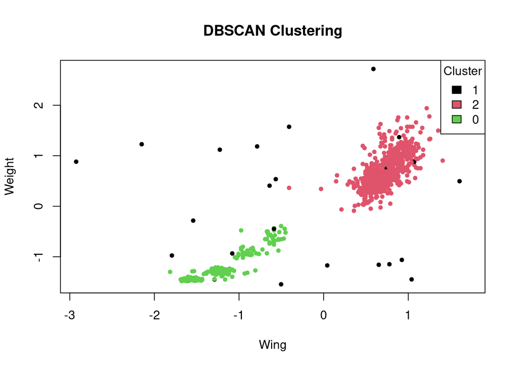

```r
# Cargar el paquete si no está cargado
if (!require('dbscan')) install.packages('dbscan')
library(dbscan)

# Asumimos que hawks_clean_scaled son los datos ya estandarizados
set.seed(123)  # Para reproducibilidad

# Aplicar DBSCAN
dbscan_result <- dbscan(hawks_clean_scaled, eps = 0.5, minPts = 5)

# Visualizar los resultados
plot(hawks_clean_scaled, col = dbscan_result$cluster + 1L, pch = 20, main = "DBSCAN Clustering")
legend("topright", legend = unique(dbscan_result$cluster), fill = 1:length(unique(dbscan_result$cluster)), title = "Cluster")
```

Se observan tres grupos diferenciados:

El grupo grande en rosa que podría representar el cluster principal.

Un grupo más pequeño en verde que parece estar bien separado del grupo principal.

Los puntos negros, que representan ruido o puntos que no se han asignado a ningún cluster.

DBSCAN parece haber identificado un posible outlier o un grupo de outliers que están alejados de las áreas de alta densidad. Si estos puntos negros son numerosos y dispersos, esto puede indicar que el valor de eps usado podría estar demasiado bajo o que el minPts está demasiado alto, causando que puntos que podrían formar un cluster sean considerados ruido.

#### 1.2.1.2 Aplicación de OPTICS

OPTICS puede proporcionar una visión más detallada de cómo los datos pueden ser agrupados en diferentes niveles de densidad.

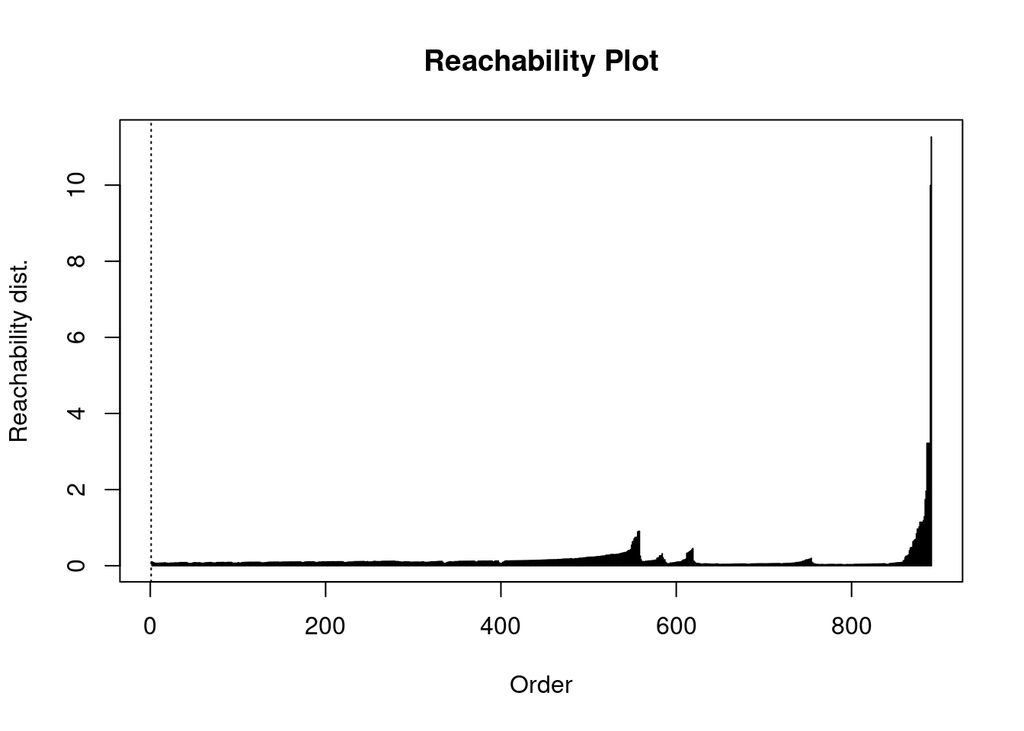

```r
# Aplicar OPTICS
optics_result <- optics(hawks_clean_scaled, minPts = 5)

# Visualizar el plot de Alcanzabilidad
plot(optics_result, main = "Reachability Plot")
```

La imagen es el Reachability Plot generado por OPTICS. Este gráfico muestra la distancia de alcanzabilidad de cada punto ordenados. Las zonas donde la línea cae casi a cero indican regiones de alta densidad (los valles), mientras que los picos altos indican áreas de baja densidad, a menudo considerados como outliers.

Este gráfico puede ser un poco más difícil de interpretar sin una referencia clara de dónde se encuentran los clusters. Sin embargo, se puede usar para ayudar a establecer un valor apropiado de eps si extraigo los clusters con un enfoque DBSCAN.

- Extracción de Clusters: Uso el método extractDBSCAN para obtener clusters a partir de los resultados de OPTICS basándome en un umbral de distancia específico.

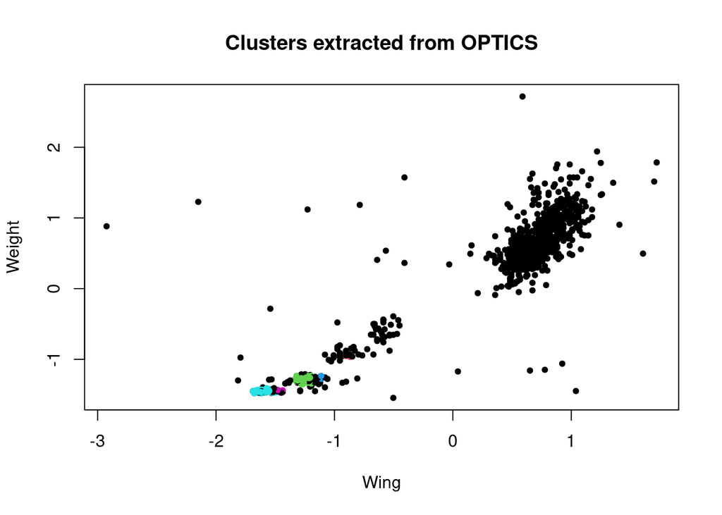

```r
# Extraer clusters
extracted_clusters <- extractDBSCAN(optics_result, eps_cl = 0.05)
plot(hawks_clean_scaled, col = extracted_clusters$cluster + 1L, pch = 20, main = "Clusters extracted from OPTICS")
```

- Clusters extraídos de OPTICS
  - La imagen muestra los clusters extraídos usando OPTICS. Parece que muchos puntos han sido clasificados como ruido (puntos negros), con unos pocos clusters pequeños identificados (colores variados).
  - Esto sugiere que el valor de eps utilizado para extraer los clusters de la estructura de OPTICS podría ser demasiado restrictivo, o que los clusters en el conjunto de datos no están bien definidos según los parámetros de densidad que OPTICS utiliza para diferenciar entre el ruido y los clusters.

#### 1.2.1.3 Ajustes de DBSCAN

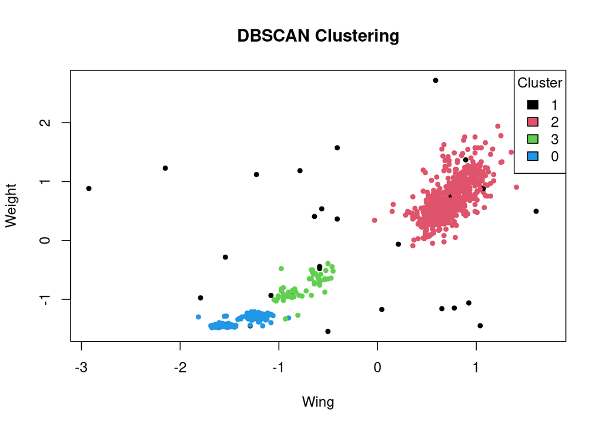

```r
# Aplicar DBSCAN
dbscan_result <- dbscan(hawks_clean_scaled, eps = 0.4, minPts = 4)

# Visualizar los resultados
plot(hawks_clean_scaled, col = dbscan_result$cluster + 1L, pch = 20, main = "DBSCAN Clustering")
legend("topright", legend = unique(dbscan_result$cluster), fill = 1:length(unique(dbscan_result$cluster)), title = "Cluster")
```

La gráfica resultante de la aplicación del algoritmo DBSCAN revela la presencia de tres conglomerados claramente definidos en el espacio de características.

Observamos que el grupo representado en rosa domina la distribución, denotando el cluster principal con una densidad significativa de puntos. Un segundo cluster, ilustrado en verde, muestra una menor cantidad de observaciones pero aún así se distingue claramente, sugiriendo una variabilidad notable dentro de los datos.

Adicionalmente, se aprecia una dispersión de puntos negros que no se asignan a ninguno de los clusters mencionados, considerados como ruido y potencialmente representando outliers o datos anómalos. La separación espacial entre los clusters y el ruido sugiere que los parámetros seleccionados para el DBSCAN están adecuadamente calibrados para discernir la estructura natural de los datos.

#### 1.2.1.4 Ajuste de Optics

```r
# Mejor manejo de la carga de paquetes
if (!requireNamespace("dbscan", quietly = TRUE)) {
  install.packages("dbscan")
}
library(dbscan)

# Convertir la matriz a un dataframe y asegurarse de que conserva los nombres de las columnas
hawks_clean_scaled <- as.data.frame(hawks_clean_scaled)
colnames(hawks_clean_scaled) <- c("Wing", "Weight", "Culmen", "Hallux")

# Comprobación de que hawks_clean_scaled es ahora un dataframe
if(is.data.frame(hawks_clean_scaled)) {
  print("hawks_clean_scaled es ahora un dataframe")
} else {
  print("hawks_clean_scaled no es un dataframe")
}
```

```
## [1] "hawks_clean_scaled es ahora un dataframe"
```

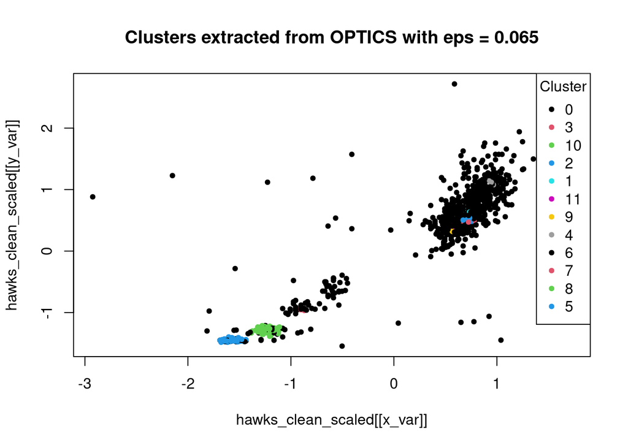

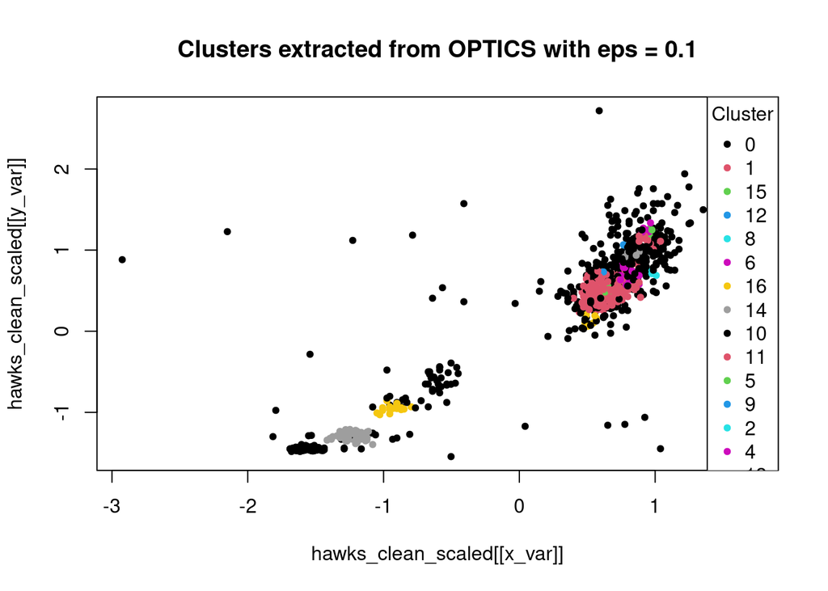

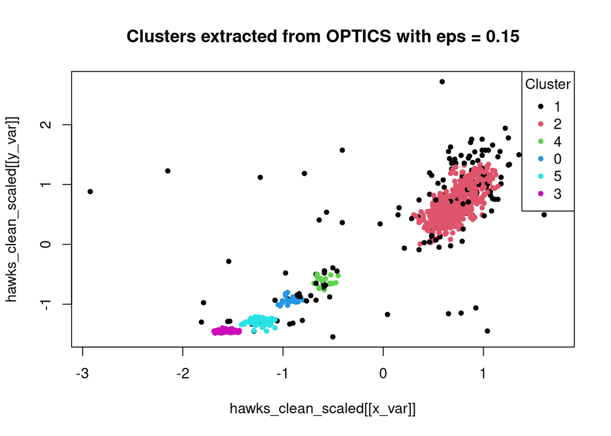

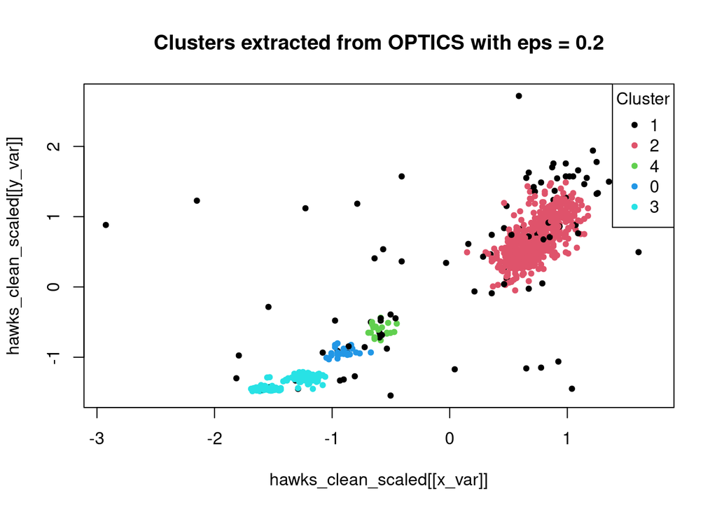

```r
# Aplicar OPTICS
optics_result <- optics(hawks_clean_scaled, minPts = 5)

# Definir un rango de valores de eps para probar
eps_cl_values <- c(0.065, 0.1, 0.15, 0.2)

# Seleccionar las variables para la visualización
x_var <- "Wing"  # Variable para el eje x
y_var <- "Weight"  # Variable para el eje y

# Definir límites del eje x e y basándonos en las columnas seleccionadas para la visualización
xlim_range <- range(hawks_clean_scaled[[x_var]], finite = TRUE)
ylim_range <- range(hawks_clean_scaled[[y_var]], finite = TRUE)

# Iterar sobre los valores de eps para extracción de clústers
for (eps_cl in eps_cl_values) {
  # Extraer clusters usando el valor actual de eps_cl
  extracted_clusters <- extractDBSCAN(optics_result, eps_cl = eps_cl)

  # Agregar la asignación de clúster al dataframe
  hawks_clean_scaled$cluster <- extracted_clusters$cluster

  # Visualizar los resultados usando las variables seleccionadas
  plot(hawks_clean_scaled[[x_var]], hawks_clean_scaled[[y_var]], col = hawks_clean_scaled$cluster + 1L, pch = 20, xlim = xlim_range, ylim = ylim_range, main = paste("Clusters extracted from OPTICS with eps =", eps_cl))
  legend("topright", legend = unique(hawks_clean_scaled$cluster), col = seq_along(unique(hawks_clean_scaled$cluster)), pch = 20, title = "Cluster")
}
```

- Con eps = 0.065: La mayoría de los puntos son clasificados como ruido (cluster 0), con unos pocos grupos pequeños detectados. Este valor parece ser demasiado restrictivo, ya que no permite que muchos puntos sean considerados parte de un cluster.
- Con eps = 0.1: Observas más clusters, aunque todavía hay una cantidad significativa de puntos clasificados como ruido. Este valor de eps parece ofrecer una mejor separación entre los clusters en comparación con eps = 0.065.
- Con eps = 0.2: La cantidad de ruido se reduce drásticamente, y los puntos se agrupan en clusters más grandes. Un valor de eps mayor facilita que más puntos se incluyan en clusters, lo que puede ser preferible si se espera que existan grupos más grandes en los datos.

## 1.3 Ejercicio 3

Realiza una comparativa de los métodos *k-means* y *DBSCAN*

### 1.3.1 Respuesta 3

#### 1.3.1.1 Comparación de Resultados: K-means vs. DBSCAN

La visualización DBSCAN parece reflejar de manera más clara la presencia de tres grupos distintos en comparación con K-means. Este resultado es consistente con el conocimiento previo de que hay tres especies distintas dentro del conjunto de datos.

- K-means:
  - K-means ha identificado tres clústeres, pero debido a su sensibilidad a outliers, se observan dos puntos distantes en un tercer clúster, lo cual podría ser un reflejo de su susceptibilidad a la variabilidad y a los valores atípicos.
  - En K-means, cada observación siempre se asignará a un clúster, incluso si es un outlier, lo cual puede conducir a clústeres potencialmente sesgados.
- DBSCAN:
  - DBSCAN ha demostrado una capacidad superior para manejar outliers, clasificándolos aparte y formando clústeres basados en la densidad de los datos.
  - Con los parámetros ajustados (eps = 0.4, minPts = 4), DBSCAN ha agrupado los datos de una manera que parece corresponder muy bien con las tres especies conocidas, proporcionando una segmentación clara y una separación de los grupos.
- Conclusión:
  - La sensibilidad a outliers de K-means frente a la robustez de DBSCAN en ese aspecto es una consideración clave en la elección del algoritmo de clustering. DBSCAN, al no requerir la especificación del número de clústeres y al poder aislar outliers, ha demostrado ser una opción más efectiva para este conjunto de datos en particular, donde el conocimiento previo de las especies apoya la existencia de tres grupos distintos.
  - Además, la combinación de análisis exploratorios, ajustes de parámetros, y el entendimiento contextual del conjunto de datos, demuestra que una aproximación metódica y bien informada es esencial para la minería de datos efectiva. Estos pasos han permitido no solo identificar el algoritmo más apropiado, sino también ajustar dicho algoritmo para alinear sus resultados con la realidad biológica conocida de las especies en estudio.

Este enfoque iterativo y ajustado al contexto es crucial para obtener insights confiables y significativos de los datos.